# Structural Divergence - Cartesian coordinates

# Introduction

We study the evolutionary divergence of proteins using the LF-ENM and comparing simulated mutants with experimental data.

In this case we studied the az family. We used the ENM ANM with R0 = 12.5 to generate mutants. We used as reference for the ENM the protein with pdb code 1bxva. The active/functional sites of the reference are:

```
##   active.site.index                                        description
## 1                37 Copper; via pros nitrogen - metal ion-binding site
## 2                74                    Copper - metal ion-binding site
## 3                77 Copper; via pros nitrogen - metal ion-binding site
## 4                82                    Copper - metal ion-binding site
```

We simulated 10 mutants of this reference for each protein of the family. The az family is of the type beta and consists of the following proteins:

```
##  [1] "1rkra" "1jzga" "1nwpa" "1dz0a" "2azaa" "1kdj"  "1m9wa" "1nin"
##  [9] "1bawa" "2b3ia" "1plb"  "1ag6"  "1plc"  "1byoa" "1paz"  "1bqk"
## [17] "1adwa" "1id2a" "2raca" "1gy1a" "1joi"  "1cuoa" "9pcy"  "7pcy"
## [25] "1iuz"  "2plt"  "1pmy"
```

[output not shown]

[output cut: 76 more lines]

# Structural divergence along sites

Here we study how structural divergence varies from site to site. We compare simulated data with empirical data.

### SDi vs site

To measure structural divergence we use SDi profiles. The following plot compares the mean SDi profiles, including standard errors (with .999 confidence level for the mean).

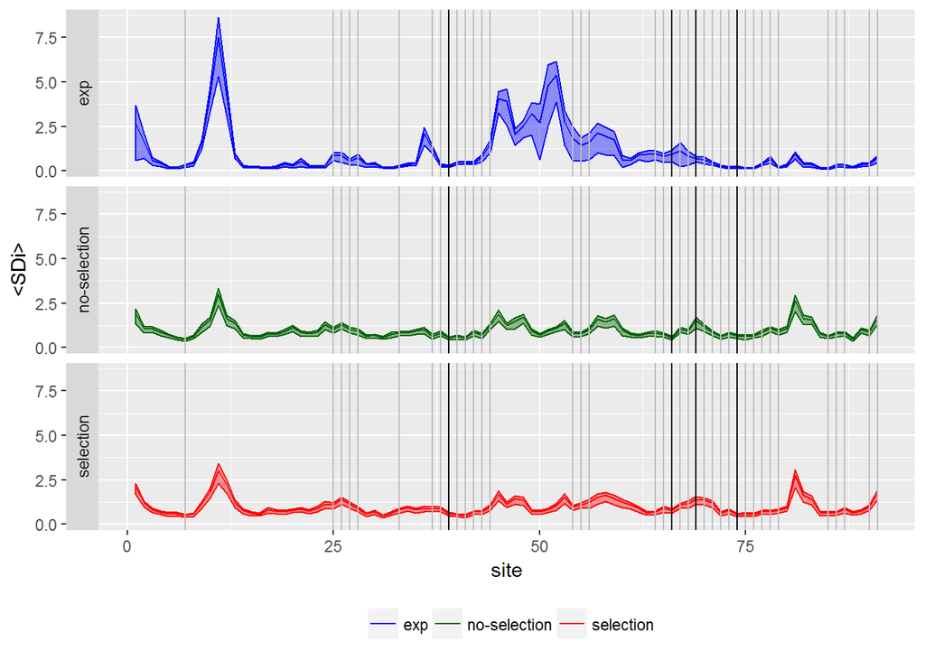

Black lines are the active sites and grey lines are their contacts

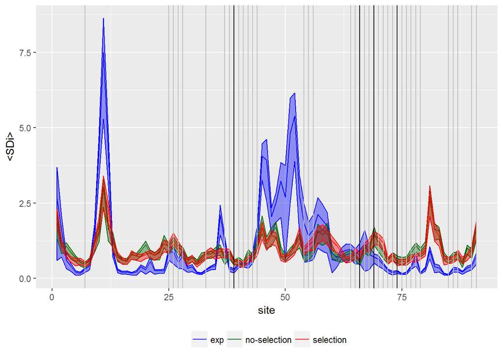

Black lines are the active sites and grey lines are their contacts

### Correlation between SDi profiles

Pearson correlation between profiles

| comparison | R |
| --- | --- |
| exp vs no-selection | 0.59 |
| exp vs selection | 0.60 |
| no-selection vs selection | 0.93 |

Spearman correlation between profiles

| comparison | R |
| --- | --- |
| exp vs no-selection | 0.59 |
| exp vs selection | 0.64 |
| no-selection vs selection | 0.86 |

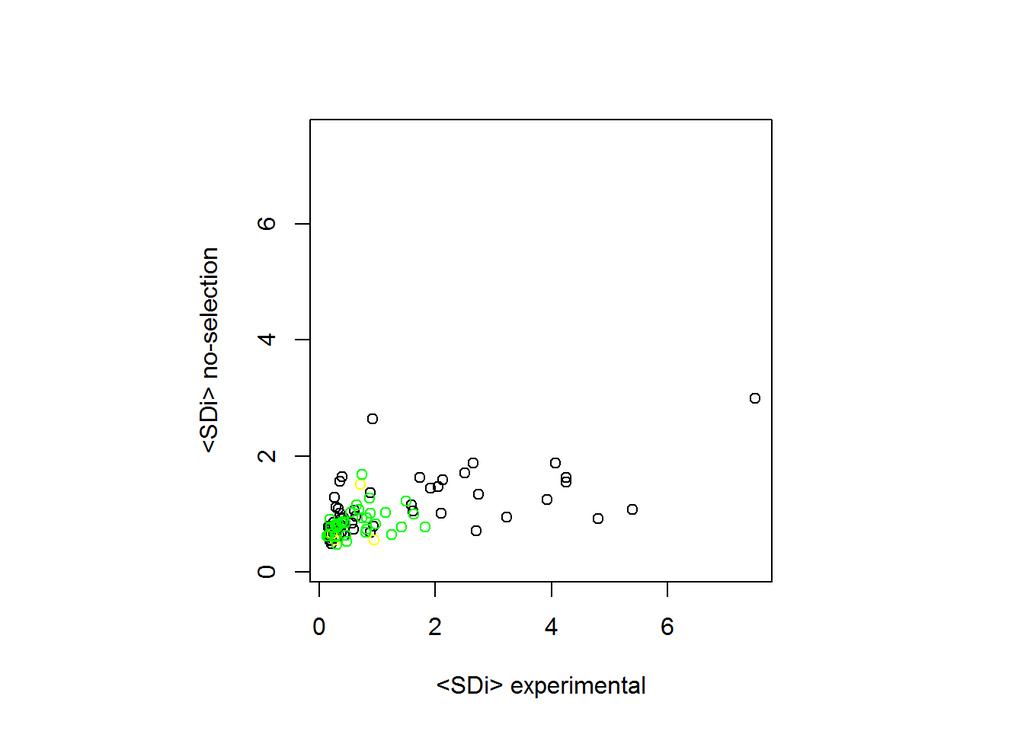

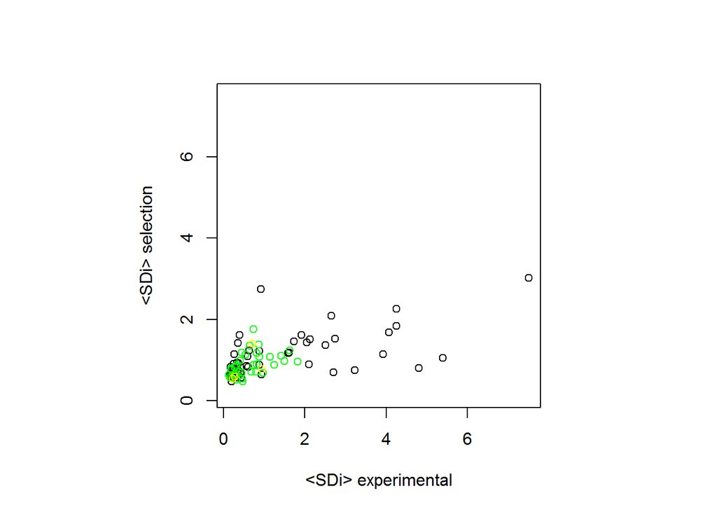

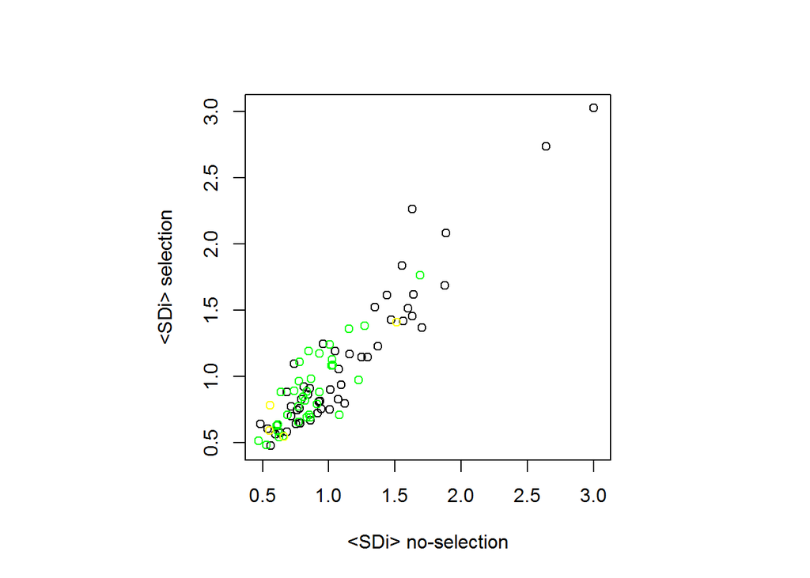

### Comparison between sqrt SDi profiles

Pearson correlation between sqrt profiles

| comparison | R |
| --- | --- |
| exp vs no-selection | 0.60 |
| exp vs selection | 0.62 |
| no-selection vs selection | 0.92 |

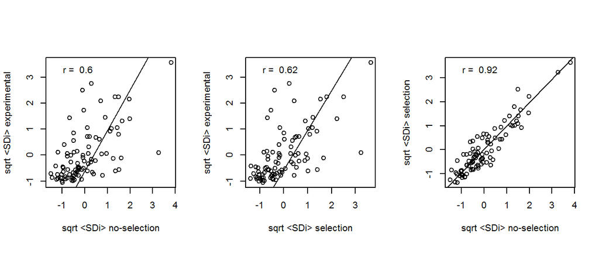

### Sequence (LPD (CN for ANM and WCN for pfANM)) - structure (SDi) comparison

In this section we compare theoretical and experimental structural divergence profiles with LPD.

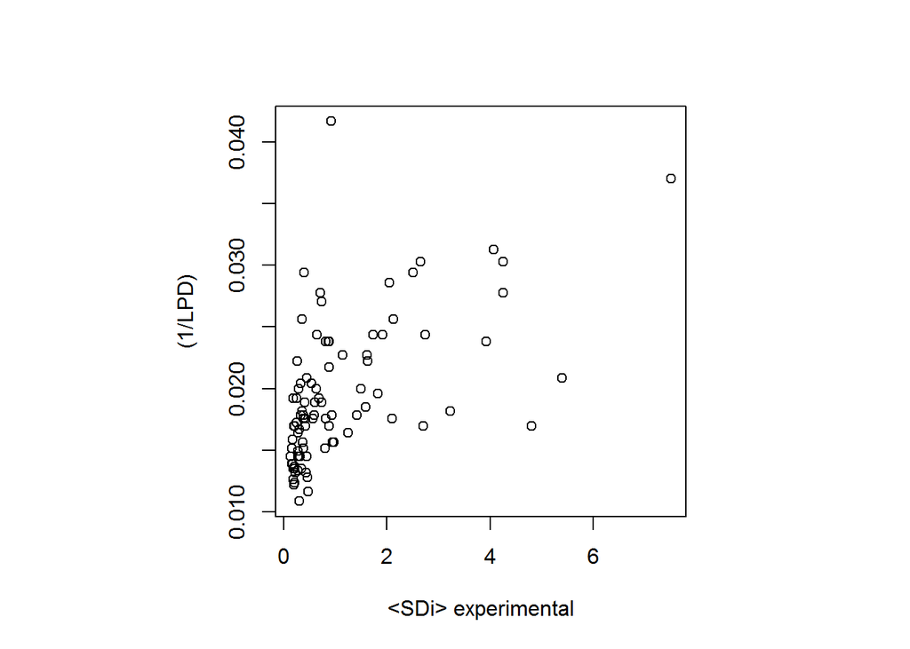

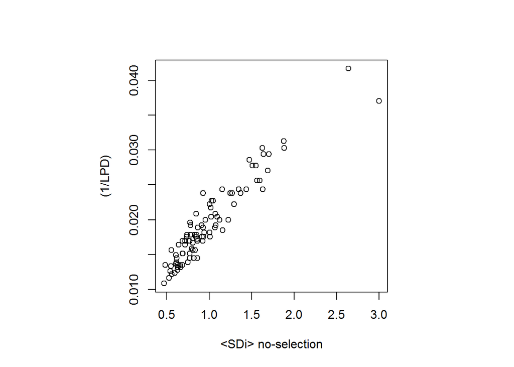

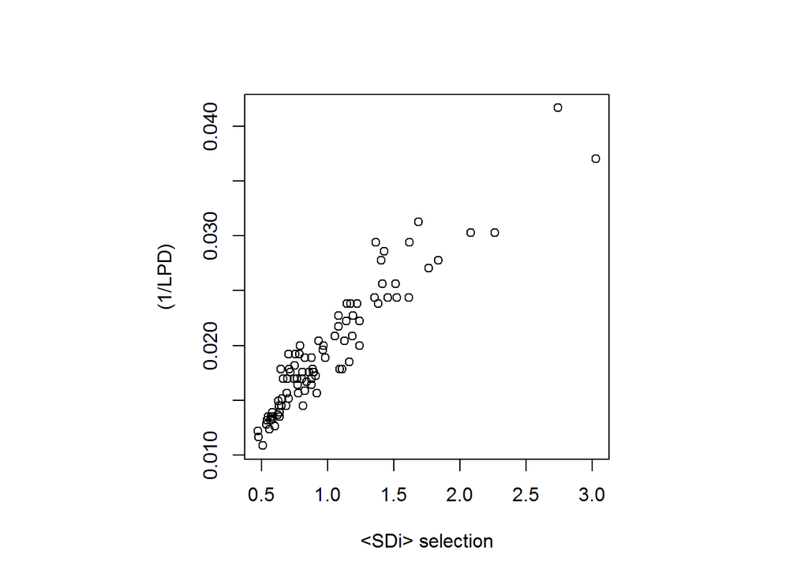

Pearson Correlation structure (SDi) - sequence (1/LPD)

| comparison | R |
| --- | --- |
| SDi experimental vs 1/LPD | 0.55 |
| SDi no-selection vs 1/LPD | 0.95 |
| SDi selection vs 1/LPD | 0.94 |

Spearman Correlation structure (SDi) - sequence (1/LPD)

| comparison | R |
| --- | --- |
| SDi experimental vs 1/LPD | 0.64 |
| SDi no-selection vs 1/LPD | 0.93 |
| SDi selection vs 1/LPD | 0.93 |

### Sequence RSA - structure (SDi) comparison

In this section we compare theoretical and experimental structural divergence profiles with RSA calculated with DSSP.

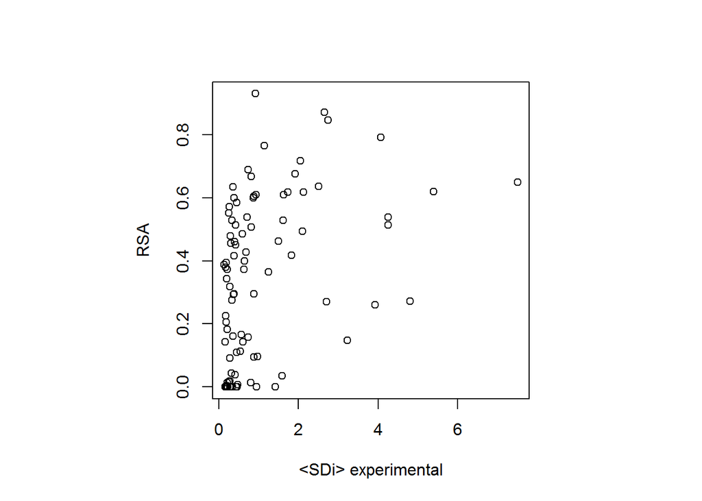

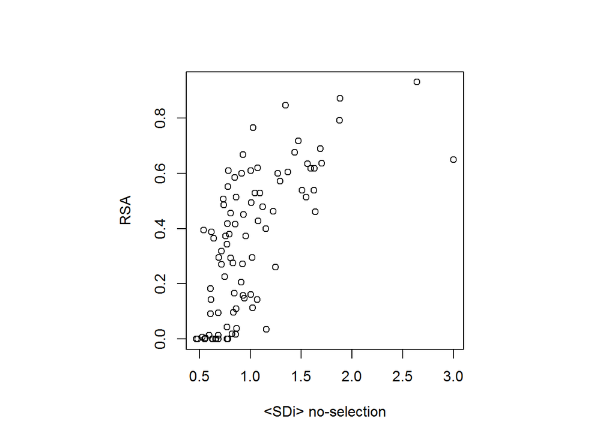

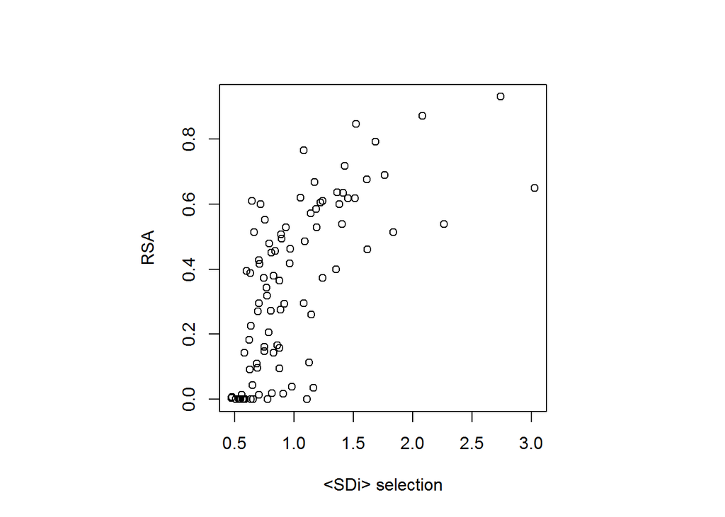

Pearson Correlation structure (SDi) - sequence RSA

| comparison | R |
| --- | --- |
| SDi experimental vs RSA | 0.38 |
| SDi no-selection vs RSA | 0.68 |
| SDi selection vs RSA | 0.67 |

Spearman Correlation structure (SDi) - sequence RSA

| comparison | R |
| --- | --- |
| SDi experimental vs RSA | 0.48 |
| SDi no-selection vs RSA | 0.73 |
| SDi selection vs RSA | 0.73 |

### Sequence MSF - structure (SDi) comparison

In this section we compare theoretical and experimental structural divergence profiles with MSF calculated with the ANM.

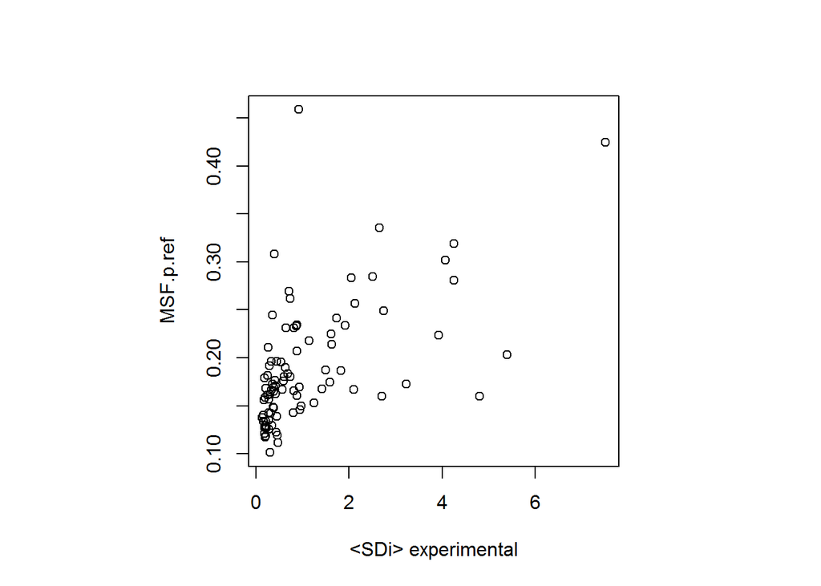

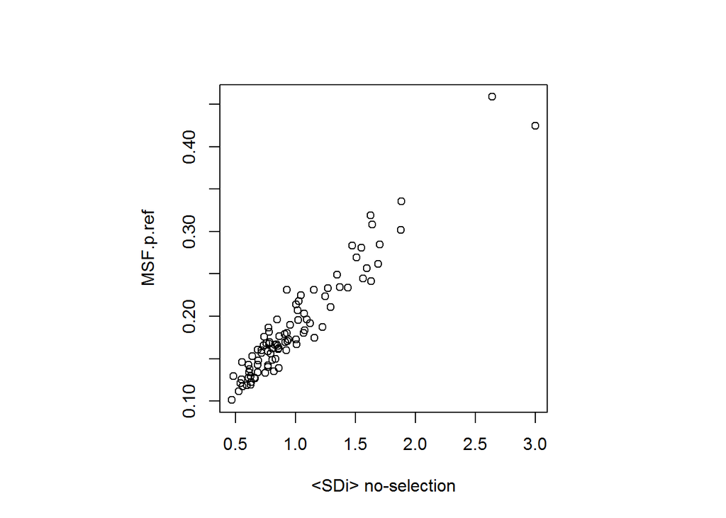

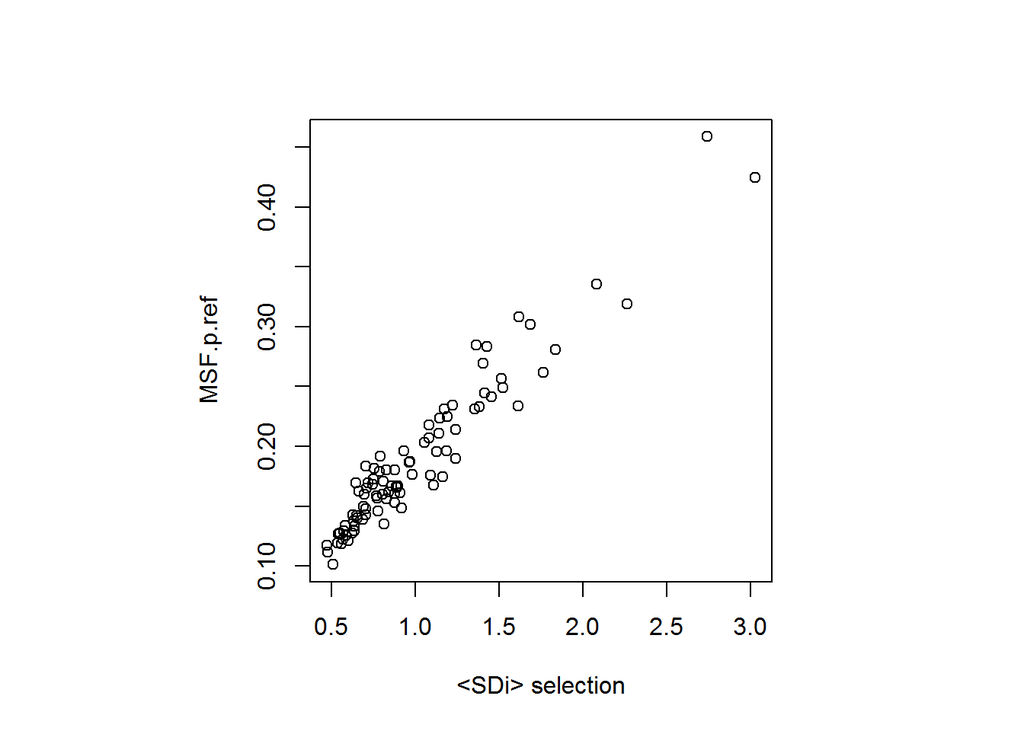

Pearson Correlation structure (SDi) - sequence MSF.p.ref

| comparison | R |
| --- | --- |
| SDi experimental vs MSF.p.ref | 0.57 |
| SDi no-selection vs MSF.p.ref | 0.96 |
| SDi selection vs MSF.p.ref | 0.96 |

Spearman Correlation structure (SDi) - sequence MSF.p.ref

| comparison | R |
| --- | --- |
| SDi experimental vs MSF.p.ref | 0.63 |
| SDi no-selection vs MSF.p.ref | 0.93 |
| SDi selection vs MSF.p.ref | 0.92 |

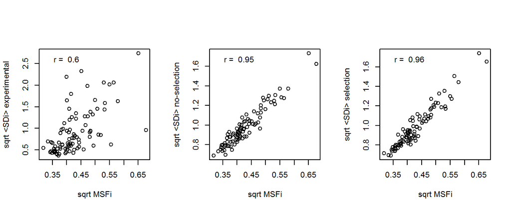

### Sequence b-factor - structure (SDi) comparison

In this section we compare theoretical and experimental structural divergence profiles with b-factor obtained from the pdb.

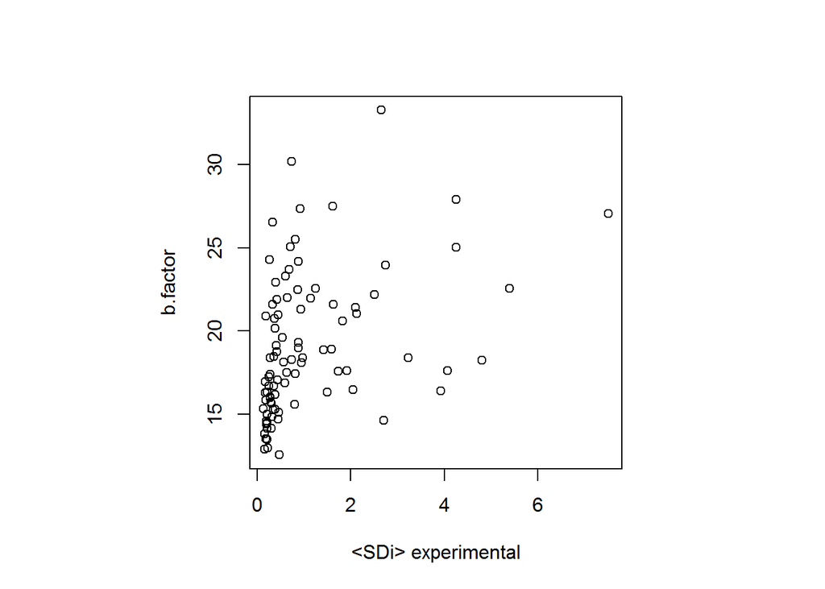

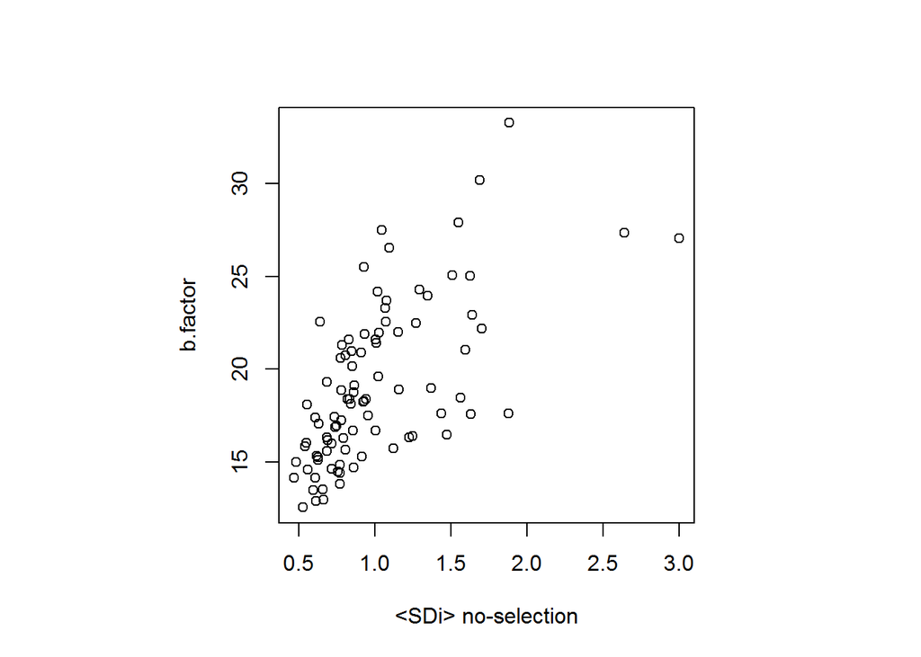

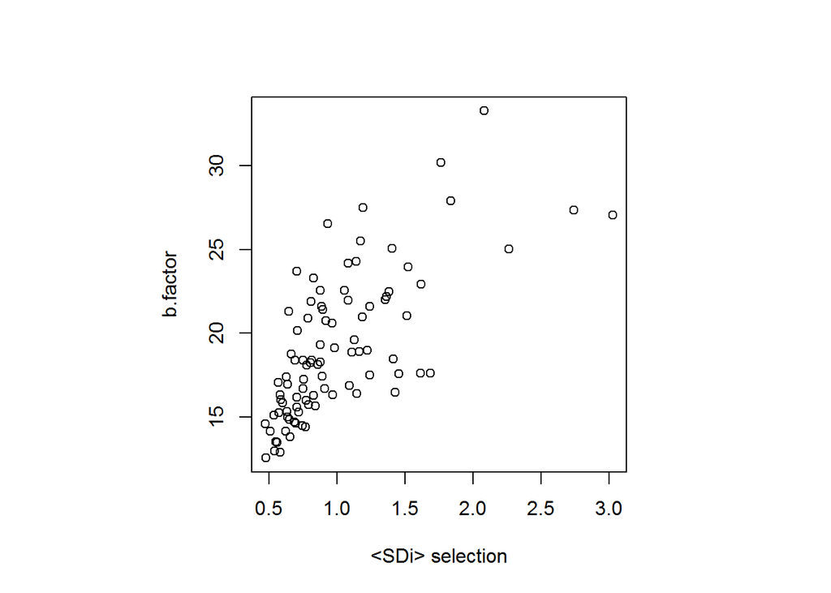

Pearson Correlation structure (SD) - sequence b.factor

| comparison | R |
| --- | --- |
| SD experimental vs b.factor | 0.39 |
| SD no-selection vs b.factor | 0.64 |
| SD selection vs b.factor | 0.70 |

Spearman Correlation structure (SD) - sequence b.factor

| comparison | R |
| --- | --- |
| SD experimental vs b.factor | 0.56 |
| SD no-selection vs b.factor | 0.70 |
| SD selection vs b.factor | 0.73 |

### Sequence b-factor - sequence MSF comparison

In this section we compare theoretical and experimental b-factors

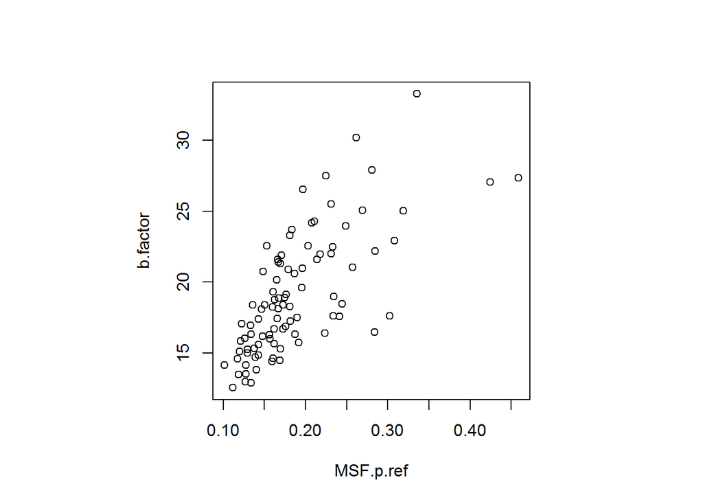

Pearson Correlation sequence MSF - sequence b.factor

| comparison | R |
| --- | --- |
| MSF vs b.factor | 0.71 |

Spearman Correlation sequence MSF - sequence b.factor

| comparison | R |
| --- | --- |
| MSF vs b.factor | 0.75 |

### Sequence comparison

In this section we compare theoretical sequence divergence profiles with sequence scores obtained from ConsurfDB. To obtain theoretical profiles, for each selection regimen, we calculated the number of times we had mutated each site and divided this number by the number of times we had tried a mutation at the site.

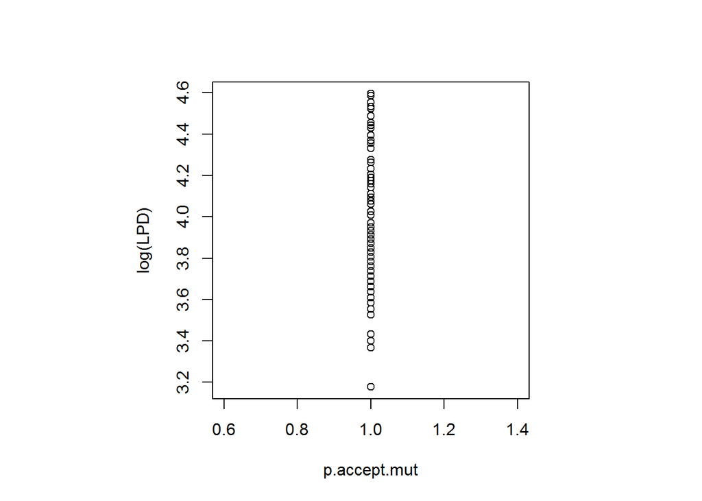

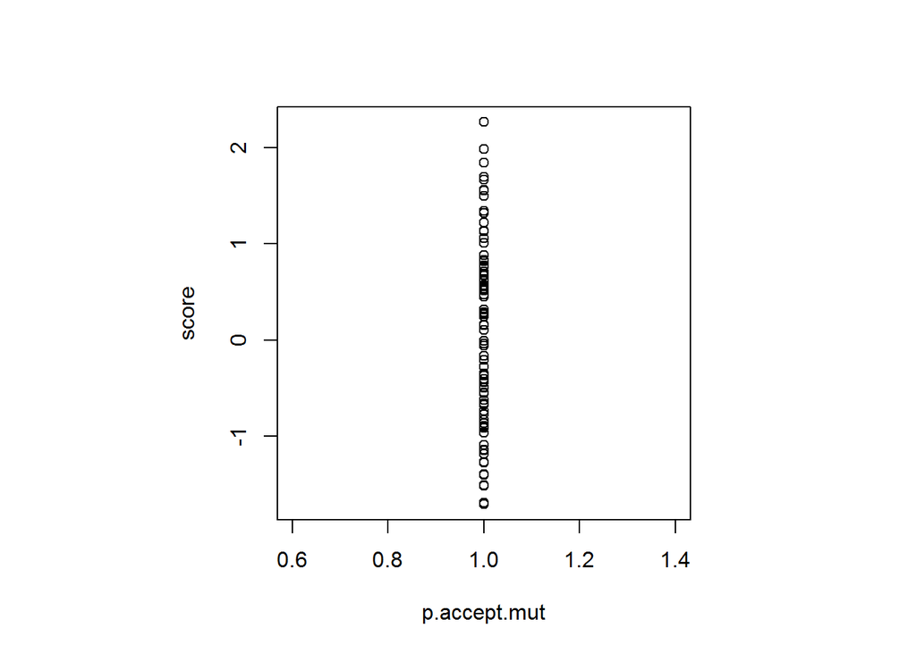

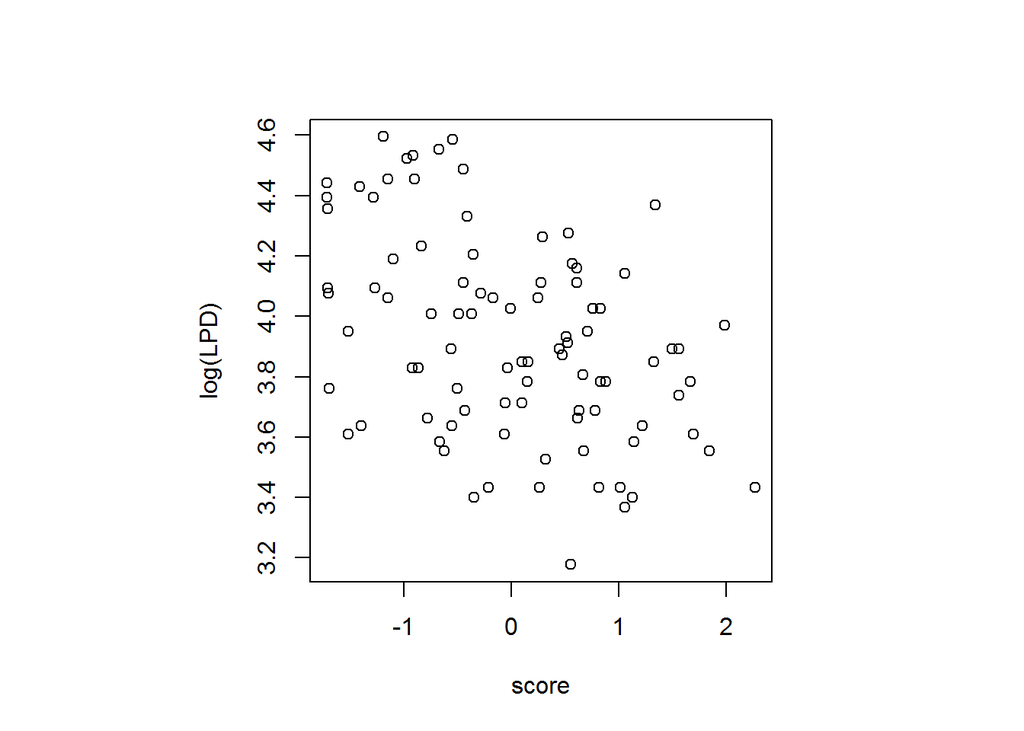

Pearson correlation between sequence profiles

| comparison | R |
| --- | --- |
| paccept no-selection vs log(LPD) | NA |
| paccept no-selection vs score | NA |
| score vs log(LPD) | -0.44 |

```
## [1] "<paccept no-selection>"
```

```
## [1] 1
```

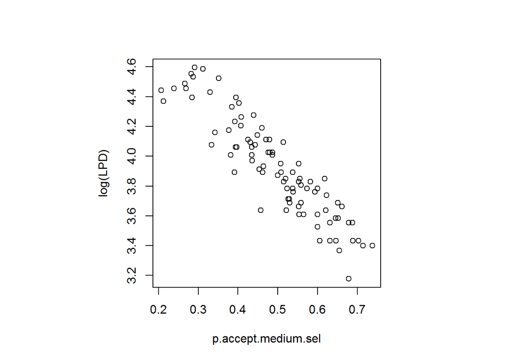

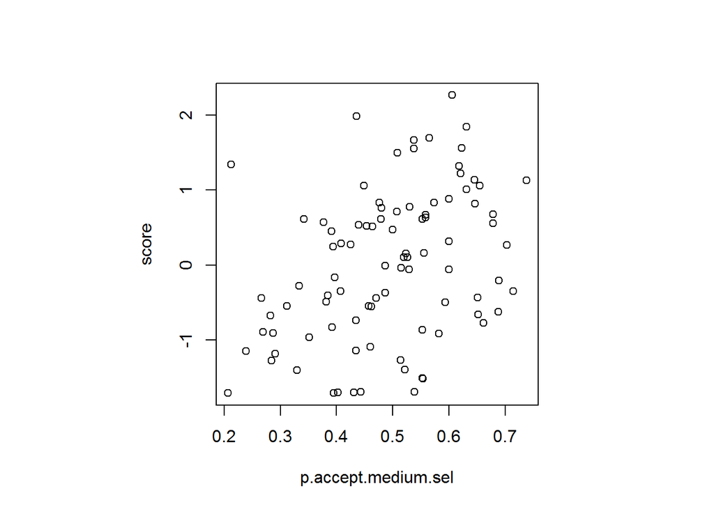

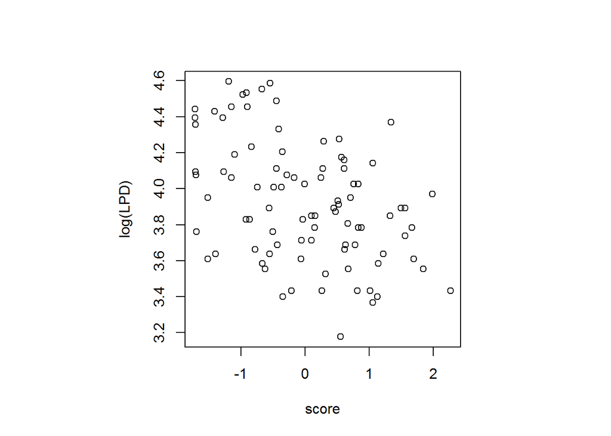

Pearson correlation between sequence profiles

| comparison | R |
| --- | --- |
| paccept selection vs log(LPD) | -0.91 |
| paccept selection vs score | 0.38 |
| score vs log(LPD) | -0.44 |

```
## [1] "<paccept selection (medium selection)>"
```

```
## [1] 0.4927429
```